# 数据集属性字段分析

## 聚类分析

```python
from sklearn.decomposition import PCA
from sklearn.cluster import KMeans
from mpl_toolkits.mplot3d import Axes3D
```

创建用于聚类分析的数据 `cdata`。剔除非数值型的列 `Id`, `groupId`, `matchId`。`matchType` 已经转为 One-Hot，因此也剔除原始列。

```python
cdrop = ['Id','groupId','matchId','matchType','winPlacePerc']
cdata = train.loc[0:math.floor(train.shape[0]*0.001), [x for x in train.columns if x not in cdrop]]
tdata = train.loc[0:math.floor(train.shape[0]*0.001), ['winPlacePerc']]
```

先尝试进行 PCA 主成分分析。尝试选用 2 个主成分。

```python
pca2 = PCA(n_components=2)
pca2.fit(cdata)
print(sum(pca2.explained_variance_ratio_))
P2 = pca2.transform(cdata)
```

```
0.8755513362711799
```

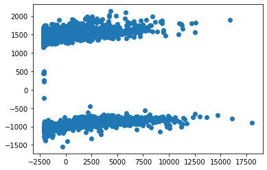

```python
plt.scatter(P2[:,0],P2[:,1])
plt.show()
```

可以观察到数据可明显产生 2 个集群。主成分分析向我们揭示了集群的数量。

再尝试 3 个主成分。

```python
pca3 = PCA(n_components=3)
pca3.fit(cdata)
print(sum(pca3.explained_variance_ratio_))
P3 = pca3.transform(cdata)
```

```
0.9900306574984697
```

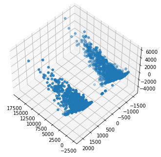

```python
fig_p3 = plt.figure()
ax = Axes3D(fig_p3, elev=48, azim=134)
ax.scatter(P3[:,0],P3[:,1],P3[:,2])
fig_p3.show()
```

仍然是大致 2 个集群，数量没有增加。

如果直接对主成分分析的结果进行聚类，效果不太理想。

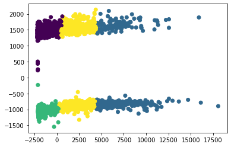

```python
kms4 = KMeans(n_clusters=4).fit(P2)
plt.scatter(P2[:,0],P2[:,1],c=kms4.labels_)
plt.show()
```

转而尝试直接对原始数据进行聚类。

```python
kmso = KMeans(n_clusters=4).fit(cdata)
```

产生的聚类中心如下。

```python
pd.DataFrame(kmso.cluster_centers_,columns=cdata.columns)
```

|  | assists | boosts | damageDealt | DBNOs | headshotKills | heals | killPlace | killPoints | kills | killStreaks | ... | roadKills | swimDistance | teamKills | vehicleDestroys | walkDistance | weaponsAcquired | winPoints | totalDistance | killsWithoutMoving | headshot_rate |
| --- | --- | --- | --- | --- | --- | --- | --- | --- | --- | --- | --- | --- | --- | --- | --- | --- | --- | --- | --- | --- | --- |
| 0 | 0.475703 | 2.933504 | 210.826051 | 1.035806 | 0.383632 | 3.759591 | 29.434783 | 4.074322e+02 | 1.485934 | 0.780051 | ... | 0.017903 | 9.920176 | 0.061381 | 0.061381 | 2215.162916 | 5.575448 | 4.908031e+02 | 7115.448820 | 0.0 | 0.150746 |
| 1 | 0.132212 | 0.317909 | 82.792632 | 0.404447 | 0.109976 | 0.494591 | 58.664063 | 3.467449e-12 | 0.518029 | 0.384014 | ... | 0.001202 | 1.552684 | 0.019832 | 0.001202 | 425.272752 | 2.706130 | 2.501110e-12 | 460.462866 | 0.0 | 0.073093 |
| 2 | 0.141571 | 0.387889 | 90.589185 | 0.490180 | 0.133388 | 0.612111 | 57.689853 | 1.240018e+03 | 0.567103 | 0.405074 | ... | 0.001637 | 1.211182 | 0.013912 | 0.000818 | 458.035629 | 2.756956 | 1.496191e+03 | 506.791020 | 0.0 | 0.081388 |
| 3 | 0.420377 | 2.521404 | 216.495277 | 1.060788 | 0.462329 | 2.772260 | 27.952911 | 4.687389e+02 | 1.750856 | 0.848459 | ... | 0.003425 | 9.770957 | 0.035959 | 0.018836 | 2510.434846 | 5.181507 | 5.659118e+02 | 3191.242111 | 0.0 | 0.159862 |

4 rows × 27 columns

从前述关联性分析可知，`killPoints` 与排名之间的关系较低。尝试可视化分析，不同聚类用不同颜色标示。

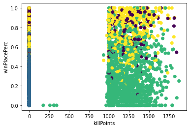

```python
plt.scatter(cdata['killPoints'],tdata['winPlacePerc'],c=kmso.labels_)
plt.xlabel('killPoints')
plt.ylabel('winPlacePerc')
plt.show()
```

同样从前述关联性分析可知，`walkDistance` 与排名之间的关系较强。我们也可视化标示一下。

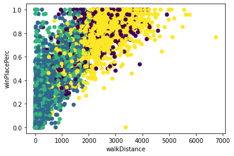

```python
plt.scatter(cdata['walkDistance'],tdata['winPlacePerc'],c=kmso.labels_)
plt.xlabel('walkDistance')
plt.ylabel('winPlacePerc')
plt.show()
```

我们再对具有较强相关性的几个变量进行标示。

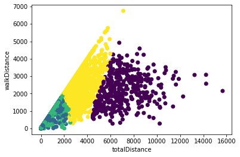

```python
plt.scatter(cdata['totalDistance'],cdata['walkDistance'],c=kmso.labels_)
plt.xlabel('totalDistance')
plt.ylabel('walkDistance')
plt.show()
```

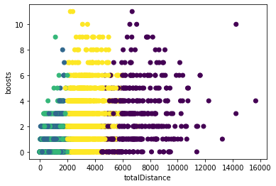

```python
plt.scatter(cdata['totalDistance'],cdata['boosts'],c=kmso.labels_)
plt.xlabel('totalDistance')
plt.ylabel('boosts')
plt.show()
```

在创建用于聚类分析的数据时，我们删除了排名列。为了检验聚类效果的好坏，来看一看各个类的排名情况。

首先，以下图标示各个颜色的顺序号。从左往右，分别为第一至第四类。

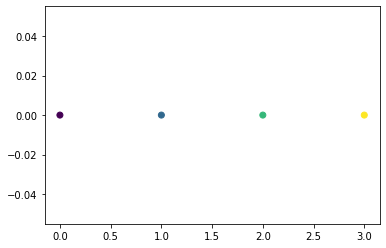

```python
plt.scatter([0,1,2,3],[0,0,0,0],c=[0,1,2,3])
plt.show()
```

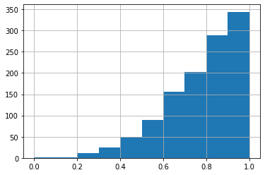

```python
tdata[kmso.labels_==0]['winPlacePerc'].hist()
plt.show()
```

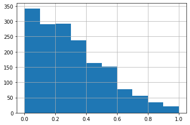

```python
tdata[kmso.labels_==1]['winPlacePerc'].hist()
plt.show()
```

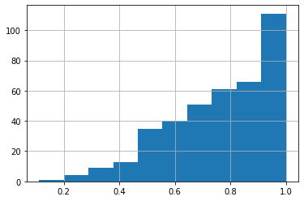

```python
tdata[kmso.labels_==2]['winPlacePerc'].hist()
plt.show()
```

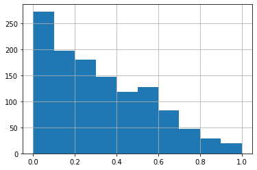

```python
tdata[kmso.labels_==3]['winPlacePerc'].hist()
plt.show()
```

可以发现，聚类得到的 4 个类里，有两个类以低排名为主，有两个类以高排名为主，具有区分性，说明聚类的效果不错。

## 结论

综上，我们可以得到了一个取得高名次的策略：  
1.由于击杀特征与排名有着最高的相关关系，因此要想取得高名次，需要击杀更多的敌人或者造成更多的伤害。  
2.移动更多的距离，当然不是随意移动，一般体现在进入淘汰圈，移动到有利地形，搜刮补给或空投，存活更长的时间。  
3.搜刮更多的道具，让自己在装备上处于优势，并且应该要擅长使用能量和治疗道具  
4.如果对自己的能力并不自信，尽量选择多排，这样更容易取得胜利

# 特征选择

```python
import gc
import time
import os
import pandas as pd
import numpy as np
from sklearn.model_selection import train_test_split
from lightgbm import LGBMRegressor
from sklearn.metrics import mean_absolute_error
```

```python
train = pd.read_csv('../input/train_V2.csv')
```

## 组合特征选择

```python
def original(df):
    return df

# 每个队伍里的玩家数量（与比赛类型相关）
def players_in_team(df):
    agg = df.groupby('groupId').size().to_frame('group_size')
    df = df.merge(agg, how='left', on='groupId')
    return df

# 每场比赛里的玩家数量
def players_in_match(df):
    agg = df.groupby('matchId').size().reset_index(name='match_size')
    df = df.merge(agg, how='left', on='matchId')
    return df

# 总距离（步行+载具+游泳）
def total_distance(df):
    df['total_distance'] = df['walkDistance'] + df['rideDistance'] + df['swimDistance']
    return df

# 使用补给总数量（治疗+能量）
def total_healsandboosts(df):
    df['healsandboosts'] = df['heals'] + df['boosts']
    return df

# Rankpoints（将小于0的部分修改为0）
def rankPoints(df):
    df['rankPoints'] = np.where(df['rankPoints'] <= 0 ,0 , df['rankPoints'])
    return df

# 爆头率
def headshots_over_kills(df):
    df['headshots_over_kills'] = df['headshotKills'] / df['kills']
    df['headshots_over_kills'] = df['headshots_over_kills'].fillna(0)
    return df

# 玩家的击杀排名在最大排名中的百分比
def killPlace_over_maxPlace(df):
    df['killPlace_over_maxPlace'] = df['killPlace'] / df['maxPlace']
    return df

# 步行距离与治疗道具使用量的比值
def walkDistance_over_heals(df):
    df['walkDistance_over_heals'] = df['walkDistance'] / df['heals']
    df['walkDistance_over_heals'] = df['walkDistance_over_heals'].replace(np.inf, 0)
    return df

# 步行距离与击杀数的比值
def walkDistance_over_kills(df):
    df['workDistance_ove_kills'] = df['walkDistance'] / df['kills']
    df['workDistance_ove_kills'] = df['workDistance_ove_kills'].fillna(0)
    df['workDistance_ove_kills'] = df['workDistance_ove_kills'].replace(np.inf, 0)
    return df

# 玩家助攻和复活队友的总数量
def teamwork(df):
    df['teamwork'] = df['assists'] + df['revives']
    return df
```

```python
# 评估列表中的每个特征的重要程度
def run_experiments(functions):
    results = []
    for function in functions:
        start = time.time()
        score = run_experiment(function)
        execution_time = time.time() - start
        result = {
            'name': function.__name__,
            'score': score,
            'exection time': f'{round(execution_time, 2)}s'
        }
        print(result)
        results.append(result)
        gc.collect()
    return pd.DataFrame(results, columns=['name', 'score', 'execution time']).sort_values(by='score')
```

```python
# 使用简单的LGB模型对结果进行预测，验证集的MSE作为该特征的重要程度
def run_experiment(function):
    df = train.copy()
    df = function(df)

    target = 'winPlacePerc'
    cols_to_drop = ['Id', 'groupId', 'matchId', 'matchType', target]
    cols_to_fit = [
        col
        for col in df.columns
        if col not in cols_to_drop
    ]

    X = df[cols_to_fit]
    y = df[target].fillna(df[target].mean())

    X_train, X_valid, y_train, y_valid = train_test_split(X, y, random_state=0)

    model = LGBMRegressor(random_state=0)
    model.fit(X_train, y_train)
    y_pred = model.predict(X_valid)
    return mean_absolute_error(y_pred, y_valid)
```

```python
run_experiments([
    original,
    teamwork,
    players_in_team,
    players_in_match,
    total_distance,
    total_healsandboosts,
    rankPoints,
    headshots_over_kills,
    killPlace_over_maxPlace,
    walkDistance_over_heals,
    walkDistance_over_kills,
])
```

[output not shown]

[output not shown]

可以发现每场比赛的玩家数量、每个队伍的玩家数量、总距离（步行+载具+游泳）、使用补给总数量（治疗+能量）、玩家的击杀排名在最大排名中的百分比这些特征得到的验证集分数要优于原始数据集，进一步说明了这些特征对预测有利。

## 统计特征选择

```python
def min_by_team(df):
    cols_to_drop = ['Id', 'groupId', 'matchId', 'matchType', 'matchDuration', 'winPlacePerc']
    features = [col for col in df.columns if col not in cols_to_drop]
    agg = df.groupby(['matchId','groupId'])[features].min().reset_index()
    return df.merge(agg, suffixes=['', '_min'], how='left', on=['matchId', 'groupId'])

def max_by_team(df):
    cols_to_drop = ['Id', 'groupId', 'matchId', 'matchType', 'matchDuration', 'winPlacePerc']
    features = [col for col in df.columns if col not in cols_to_drop]
    agg = df.groupby(['matchId', 'groupId'])[features].max().reset_index()
    return df.merge(agg, suffixes=['', '_max'], how='left', on=['matchId', 'groupId'])

def sum_by_team(df):
    cols_to_drop = ['Id', 'groupId', 'matchId', 'matchType', 'matchDuration', 'winPlacePerc']
    features = [col for col in df.columns if col not in cols_to_drop]
    agg = df.groupby(['matchId', 'groupId'])[features].sum().reset_index()
    return df.merge(agg, suffixes=['', '_sum'], how='left', on=['matchId', 'groupId'])

def median_by_team(df):
    cols_to_drop = ['Id', 'groupId', 'matchId', 'matchType', 'matchDuration', 'winPlacePerc']
    features = [col for col in df.columns if col not in cols_to_drop]
    agg = df.groupby(['matchId', 'groupId'])[features].median().reset_index()
    return df.merge(agg, suffixes=['', '_median'], how='left', on=['matchId', 'groupId'])

def mean_by_team(df):
    cols_to_drop = ['Id', 'groupId', 'matchId', 'matchType', 'matchDuration', 'winPlacePerc']
    features = [col for col in df.columns if col not in cols_to_drop]
    agg = df.groupby(['matchId', 'groupId'])[features].mean().reset_index()
    return df.merge(agg, suffixes=['', '_mean'], how='left', on=['matchId', 'groupId'])

def rank_by_team_mean(df):
    cols_to_drop = ['Id', 'groupId', 'matchId', 'matchType', 'matchDuration', 'winPlacePerc']
    features = [col for col in df.columns if col not in cols_to_drop]
    agg = df.groupby(['matchId', 'groupId'])[features].mean()
    agg = agg.groupby('matchId')[features].rank(pct=True).reset_index()
    return df.merge(agg, suffixes=['', '_mean_rank'], how='left', on=['matchId', 'groupId'])

def rank_by_team_max(df):
    cols_to_drop = ['Id', 'groupId', 'matchId', 'matchType', 'matchDuration', 'winPlacePerc']
    features = [col for col in df.columns if col not in cols_to_drop]
    agg = df.groupby(['matchId', 'groupId'])[features].mean()
    agg = agg.groupby('matchId')[features].rank(pct=True).reset_index()
    return df.merge(agg, suffixes=['', '_max_rank'], how='left', on=['matchId', 'groupId'])

def rank_by_team_min(df):
    cols_to_drop = ['Id', 'groupId', 'matchId', 'matchType', 'matchDuration', 'winPlacePerc']
    features = [col for col in df.columns if col not in cols_to_drop]
    agg = df.groupby(['matchId', 'groupId'])[features].mean()
    agg = agg.groupby('matchId')[features].rank(pct=True).reset_index()
    return df.merge(agg, suffixes=['', '_min_rank'], how='left', on=['matchId', 'groupId'])

def rank_by_team_median(df):
    cols_to_drop = ['Id', 'groupId', 'matchId', 'matchType', 'matchDuration', 'winPlacePerc']
    features = [col for col in df.columns if col not in cols_to_drop]
    agg = df.groupby(['matchId', 'groupId'])[features].median()
    agg = agg.groupby('matchId')[features].rank(pct=True).reset_index()
    return df.merge(agg, suffixes=['', '_median_rank'], how='left', on=['matchId', 'groupId'])

def mean_by_match(df):
    cols_to_drop = ['Id', 'groupId', 'matchId', 'matchType', 'matchDuration', 'winPlacePerc']
    features = [col for col in df.columns if col not in cols_to_drop]
    agg = df.groupby(['matchId'])[features].agg('mean').reset_index()
    return df.merge(agg, suffixes=["", "_match_mean"], how='left', on=['matchId'])
```

```python
run_experiments([
    original,
    min_by_team,
    max_by_team,
    sum_by_team,
    median_by_team,
    mean_by_team,
    mean_by_match,
    rank_by_team_min,
    rank_by_team_max,
    rank_by_team_median,
    rank_by_team_mean
])
```

```
{'name': 'original', 'score': 0.06040569264166316, 'exection time': '20.47s'}
{'name': 'min_by_team', 'score': 0.05710791111924572, 'exection time': '69.77s'}
{'name': 'max_by_team', 'score': 0.049371616400010886, 'exection time': '70.11s'}
{'name': 'sum_by_team', 'score': 0.05305346761468867, 'exection time': '74.28s'}
{'name': 'median_by_team', 'score': 0.05293310586643201, 'exection time': '65.37s'}
{'name': 'mean_by_team', 'score': 0.05221497300384134, 'exection time': '63.03s'}
{'name': 'mean_by_match', 'score': 0.05490459961844926, 'exection time': '48.0s'}
{'name': 'rank_by_team_min', 'score': 0.04553478309255459, 'exection time': '76.53s'}
{'name': 'rank_by_team_max', 'score': 0.04553478309255459, 'exection time': '77.51s'}
{'name': 'rank_by_team_median', 'score': 0.0446130924981313, 'exection time': '77.37s'}
{'name': 'rank_by_team_mean', 'score': 0.04553478309255459, 'exection time': '76.47s'}
```

|  | name | score | execution time |
| --- | --- | --- | --- |
| 9 | rank_by_team_median | 0.044613 | NaN |
| 7 | rank_by_team_min | 0.045535 | NaN |
| 8 | rank_by_team_max | 0.045535 | NaN |
| 10 | rank_by_team_mean | 0.045535 | NaN |
| 2 | max_by_team | 0.049372 | NaN |
| 5 | mean_by_team | 0.052215 | NaN |
| 4 | median_by_team | 0.052933 | NaN |
| 3 | sum_by_team | 0.053053 | NaN |
| 6 | mean_by_match | 0.054905 | NaN |
| 1 | min_by_team | 0.057108 | NaN |
| 0 | original | 0.060406 | NaN |

可以发现统计特征的构建都对预测的结果有一定的提升，但统计特征的构建占用较多的内存，因此我们并不使用全部的统计特征

## 原始特征选择

```python
import eli5
from eli5.sklearn import PermutationImportance

target = 'winPlacePerc'
cols_to_drop = ['Id', 'groupId', 'matchId', 'matchType', target]
cols_to_fit = [col for col in train.columns if col not in cols_to_drop]

X = train[cols_to_fit]
y = train[target].fillna(train[target].mean())

X_train, X_valid, y_train, y_valid = train_test_split(X, y, random_state=0)

model = LGBMRegressor(random_state=0)
model.fit(X_train, y_train)

perm = PermutationImportance(model, random_state=42).fit(X_valid, y_valid)
eli5.show_weights(perm, feature_names=list(cols_to_fit))
```

| Weight | Feature |
| --- | --- |
| 1.3475 ± 0.0029 | killPlace |
| 0.3965 ± 0.0007 | walkDistance |
| 0.2445 ± 0.0002 | kills |
| 0.0512 ± 0.0002 | numGroups |
| 0.0271 ± 0.0001 | matchDuration |
| 0.0226 ± 0.0000 | maxPlace |
| 0.0127 ± 0.0001 | killStreaks |
| 0.0061 ± 0.0001 | boosts |
| 0.0056 ± 0.0000 | rideDistance |
| 0.0028 ± 0.0001 | weaponsAcquired |
| 0.0027 ± 0.0000 | DBNOs |
| 0.0012 ± 0.0000 | assists |
| 0.0009 ± 0.0000 | heals |
| 0.0006 ± 0.0000 | rankPoints |
| 0.0004 ± 0.0000 | winPoints |
| 0.0003 ± 0.0000 | revives |
| 0.0003 ± 0.0000 | longestKill |
| 0.0001 ± 0.0000 | damageDealt |
| 0.0001 ± 0.0000 | swimDistance |
| 0.0001 ± 0.0000 | teamKills |
| *… 4 more …* |  |

Permutation Importance 提供了一个和模型无关的计算特征重要性的方法, 其基本思路如下：  
选择一个特征  
在数据集上对该特征的所有值进行随机排列  
计算新的预测结果  
如果新旧结果的差异不大那么说明该特征重要性低，如果新旧结果差异显著，那么说明该特征对模型的影响也是比较显著的

我们使用eli5库+LGB模型计算每个原始特征在预测结果中所占的权重，可以发现与前期数据分析的结果一致，与击杀有关的特征对预测结果的影响非常大，接下来就是距离数据、道具的使用量和武器等特征。

# 特征工程

```python
%matplotlib inline
import pandas as pd
import numpy as np
import matplotlib.pyplot as plt
import seaborn as sns
import itertools
import gc
import os
import sys

from sklearn import preprocessing
from sklearn.model_selection import train_test_split
from sklearn.metrics import mean_squared_error,mean_absolute_error
from sklearn.ensemble import RandomForestRegressor
from timeit import default_timer as timer

import lightgbm as lgb

from keras.models import Sequential
from keras.layers import Dense
from keras.callbacks import ModelCheckpoint
```

```python
# 通过类型转换节省内存空间
def reduce_mem_usage(df):
    """ iterate through all the columns of a dataframe and modify the data type
        to reduce memory usage.
    """
    start_mem = df.memory_usage().sum() / 1024**2

    for col in df.columns:
        col_type = df[col].dtype

        if col_type != object:
            c_min = df[col].min()
            c_max = df[col].max()
            if str(col_type)[:3] == 'int':
                if c_min > np.iinfo(np.int8).min and c_max < np.iinfo(np.int8).max:
                    df[col] = df[col].astype(np.int8)
                elif c_min > np.iinfo(np.int16).min and c_max < np.iinfo(np.int16).max:
                    df[col] = df[col].astype(np.int16)
                elif c_min > np.iinfo(np.int32).min and c_max < np.iinfo(np.int32).max:
                    df[col] = df[col].astype(np.int32)
                elif c_min > np.iinfo(np.int64).min and c_max < np.iinfo(np.int64).max:
                    df[col] = df[col].astype(np.int64)
            else:
                if c_min > np.finfo(np.float32).min and c_max < np.finfo(np.float32).max:
                    df[col] = df[col].astype(np.float32)
                else:
                    df[col] = df[col].astype(np.float64)

    end_mem = df.memory_usage().sum() / 1024**2
    print('Memory usage of dataframe is {:.2f} MB --> {:.2f} MB (Decreased by {:.1f}%)'.format(
        start_mem, end_mem, 100 * (start_mem - end_mem) / start_mem))
    return df
```

```python
def state(message,start = True, time = 0):
    if(start):
        print(f'Working on {message} ... ')
    else :
        print(f'Working on {message} took ({round(time , 3)}) Sec \n')
```

```python
# Import dataset
df_train = pd.read_csv('../input/train_V2.csv')
df_test = pd.read_csv('../input/test_V2.csv')

# Reduce memory use
df_train=reduce_mem_usage(df_train)
df_test=reduce_mem_usage(df_test)

# Show some data
df_train.head()
df_train.describe()
```

```
Memory usage of dataframe is 983.90 MB --> 339.28 MB (Decreased by 65.5%)
Memory usage of dataframe is 413.18 MB --> 140.19 MB (Decreased by 66.1%)
```

|  | assists | boosts | damageDealt | DBNOs | headshotKills | heals | killPlace | killPoints | kills | killStreaks | ... | revives | rideDistance | roadKills | swimDistance | teamKills | vehicleDestroys | walkDistance | weaponsAcquired | winPoints | winPlacePerc |
| --- | --- | --- | --- | --- | --- | --- | --- | --- | --- | --- | --- | --- | --- | --- | --- | --- | --- | --- | --- | --- | --- |
| count | 4.446966e+06 | 4.446966e+06 | 4.446966e+06 | 4.446966e+06 | 4.446966e+06 | 4.446966e+06 | 4.446966e+06 | 4.446966e+06 | 4.446966e+06 | 4.446966e+06 | ... | 4.446966e+06 | 4.446966e+06 | 4.446966e+06 | 4.446966e+06 | 4.446966e+06 | 4.446966e+06 | 4.446966e+06 | 4.446966e+06 | 4.446966e+06 | 4.446965e+06 |
| mean | 2.338149e-01 | 1.106908e+00 | 1.307172e+02 | 6.578755e-01 | 2.268196e-01 | 1.370147e+00 | 4.759935e+01 | 5.050060e+02 | 9.247833e-01 | 5.439551e-01 | ... | 1.646590e-01 | 6.061160e+02 | 3.496091e-03 | 4.509323e+00 | 2.386841e-02 | 7.918208e-03 | 1.154218e+03 | 3.660488e+00 | 6.064601e+02 | 4.728218e-01 |
| std | 5.885731e-01 | 1.715794e+00 | 1.707806e+02 | 1.145743e+00 | 6.021553e-01 | 2.679982e+00 | 2.746294e+01 | 6.275049e+02 | 1.558445e+00 | 7.109721e-01 | ... | 4.721671e-01 | 1.498344e+03 | 7.337297e-02 | 3.050220e+01 | 1.673935e-01 | 9.261157e-02 | 1.183497e+03 | 2.456544e+00 | 7.397004e+02 | 3.074050e-01 |
| min | 0.000000e+00 | 0.000000e+00 | 0.000000e+00 | 0.000000e+00 | 0.000000e+00 | 0.000000e+00 | 1.000000e+00 | 0.000000e+00 | 0.000000e+00 | 0.000000e+00 | ... | 0.000000e+00 | 0.000000e+00 | 0.000000e+00 | 0.000000e+00 | 0.000000e+00 | 0.000000e+00 | 0.000000e+00 | 0.000000e+00 | 0.000000e+00 | 0.000000e+00 |
| 25% | 0.000000e+00 | 0.000000e+00 | 0.000000e+00 | 0.000000e+00 | 0.000000e+00 | 0.000000e+00 | 2.400000e+01 | 0.000000e+00 | 0.000000e+00 | 0.000000e+00 | ... | 0.000000e+00 | 0.000000e+00 | 0.000000e+00 | 0.000000e+00 | 0.000000e+00 | 0.000000e+00 | 1.551000e+02 | 2.000000e+00 | 0.000000e+00 | 2.000000e-01 |
| 50% | 0.000000e+00 | 0.000000e+00 | 8.424000e+01 | 0.000000e+00 | 0.000000e+00 | 0.000000e+00 | 4.700000e+01 | 0.000000e+00 | 0.000000e+00 | 0.000000e+00 | ... | 0.000000e+00 | 0.000000e+00 | 0.000000e+00 | 0.000000e+00 | 0.000000e+00 | 0.000000e+00 | 6.856000e+02 | 3.000000e+00 | 0.000000e+00 | 4.583000e-01 |
| 75% | 0.000000e+00 | 2.000000e+00 | 1.860000e+02 | 1.000000e+00 | 0.000000e+00 | 2.000000e+00 | 7.100000e+01 | 1.172000e+03 | 1.000000e+00 | 1.000000e+00 | ... | 0.000000e+00 | 1.909750e-01 | 0.000000e+00 | 0.000000e+00 | 0.000000e+00 | 0.000000e+00 | 1.976000e+03 | 5.000000e+00 | 1.495000e+03 | 7.407000e-01 |
| max | 2.200000e+01 | 3.300000e+01 | 6.616000e+03 | 5.300000e+01 | 6.400000e+01 | 8.000000e+01 | 1.010000e+02 | 2.170000e+03 | 7.200000e+01 | 2.000000e+01 | ... | 3.900000e+01 | 4.071000e+04 | 1.800000e+01 | 3.823000e+03 | 1.200000e+01 | 5.000000e+00 | 2.578000e+04 | 2.360000e+02 | 2.013000e+03 | 1.000000e+00 |

8 rows × 25 columns

## 对数据进行简单清洗

```python
# 由于百分比是按照本局的最差名次来计算的，而不是小队的数量，并且本局最差名次与小队数量存在冗余，因此删除
# 由于最远击杀距离统计并不准确 rankPoints官方建议谨慎使用，因此删除
df_train = df_train.drop(['longestKill', 'numGroups', 'rankPoints'], axis=1)
df_test = df_test.drop(['longestKill', 'numGroups', 'rankPoints'], axis=1)

# 删除缺失值
df_train[df_train['winPlacePerc'].isnull()]
df_train.drop(2744604, inplace=True)
```

## 构建新特征

```python
def feature_engineering(df,is_train=True):
    if is_train:
        df = df[df['maxPlace'] > 1]

    state('totalDistance')
    s = timer()
    df['totalDistance'] = df['rideDistance'] + df["walkDistance"] + df["swimDistance"]
    e = timer()
    state('totalDistance', False, e - s)

    state('killPlace_over_maxPlace')
    s = timer()
    df['killPlace_over_maxPlace'] = df['killPlace'] / df['maxPlace']
    e = timer()
    state('killPlace_over_maxPlace', False, e - s)

    state('healsandboosts')
    s = timer()
    df['healsandboosts'] = df['heals'] + df['boosts']
    e = timer()
    state('healsandboosts', False, e - s)

    target = 'winPlacePerc'
    features = list(df.columns)

    # 去掉标称属性特征
    features.remove("Id")
    features.remove("matchId")
    features.remove("groupId")
    features.remove("matchDuration")
    features.remove("matchType")

    y = None
    if is_train:
        y = np.array(df.groupby(['matchId', 'groupId'])[target].agg('mean'), dtype=np.float64)
        # 从特征中去掉百分比排名（预测目标）
        features.remove(target)

    # 统计同场比赛中同组内的各个特征的平均值及其在该场比赛下的百分比
    print("get group mean feature")
    agg = df.groupby(['matchId', 'groupId'])[features].agg('mean')
    agg_rank = agg.groupby(['matchId'])[features].rank(pct=True).reset_index()


    #创建一个以matchId和groupId为索引的新数据集
    if is_train:
        df_out = agg.reset_index()[['matchId', 'groupId']]
    else:
        df_out = df[['matchId', 'groupId']]

    # 将新特征与df_out根据matchId和groupId合并
    df_out = df_out.merge(agg.reset_index(), suffixes=["", ""], how='left', on=['matchId', 'groupId'])
    df_out = df_out.merge(agg_rank, suffixes=["_mean", "_mean_rank"], how='left', on=['matchId', 'groupId'])

    # 统计同场比赛中同组内的各个特征的中值及其在该场比赛下的百分比
    print("get group median feature")
    agg = df.groupby(['matchId','groupId'])[features].agg('median')
    agg_rank = agg.groupby('matchId')[features].rank(pct=True).reset_index()

    # 将新特征与df_out根据matchId和groupId合并
    df_out = df_out.merge(agg.reset_index(), suffixes=["", ""], how='left', on=['matchId', 'groupId'])
    df_out = df_out.merge(agg_rank, suffixes=["_median", "_median_rank"], how='left', on=['matchId', 'groupId'])

    # 统计同场比赛中同组内的各个特征的最大值及其在该场比赛下的百分比
    print("get group max feature")
    agg = df.groupby(['matchId','groupId'])[features].agg('max')
    agg_rank = agg.groupby('matchId')[features].rank(pct=True).reset_index()

    # 将新特征与df_out根据matchId和groupId合并
    df_out = df_out.merge(agg.reset_index(), suffixes=["", ""], how='left', on=['matchId', 'groupId'])
    df_out = df_out.merge(agg_rank, suffixes=["_max", "_max_rank"], how='left', on=['matchId', 'groupId'])

    # 统计同场比赛中同组内的各个特征的最小值及其在该场比赛下的百分比
    print("get group min feature")
    agg = df.groupby(['matchId','groupId'])[features].agg('min')
    agg_rank = agg.groupby('matchId')[features].rank(pct=True).reset_index()

    # 将新特征与df_out根据matchId和groupId合并
    df_out = df_out.merge(agg.reset_index(), suffixes=["", ""], how='left', on=['matchId', 'groupId'])
    df_out = df_out.merge(agg_rank, suffixes=["_min", "_min_rank"], how='left', on=['matchId', 'groupId'])

    # 统计同场比赛中同组内的各个特征的和及其在该场比赛下的百分比
    print("get group max feature")
    agg = df.groupby(['matchId','groupId'])[features].agg('sum')
    agg_rank = agg.groupby('matchId')[features].rank(pct=True).reset_index()

    # 将新特征与df_out根据matchId和groupId合并
    print("get group sum feature")
    df_out = df_out.merge(agg.reset_index(), suffixes=["", ""], how='left', on=['matchId', 'groupId'])
    df_out = df_out.merge(agg_rank, suffixes=["_sum", "_sum_rank"], how='left', on=['matchId', 'groupId'])

    # 统计同场比赛中每个小组的人员数量
    print("get group size feature")
    agg = df.groupby(['matchId','groupId']).size().reset_index(name='group_size')

    # 将Group_size特征与df_out根据matchId和groupId合并
    df_out = df_out.merge(agg, how='left', on=['matchId', 'groupId'])

    # 统计同场比赛下的特征平均值
    print("get match mean feature")
    agg = df.groupby(['matchId'])[features].agg('mean').reset_index()
    # 将新特征与df_out根据matchId合并
    df_out = df_out.merge(agg, suffixes=["", "_match_mean"], how='left', on=['matchId'])

    # 统计同场比赛中小组数量
    print("get match size feature")
    agg = df.groupby(['matchId']).size().reset_index(name='match_size')
    # 将新特征与df_out根据matchId合并
    df_out = df_out.merge(agg, how='left', on=['matchId'])

    # 删除matchId和groupId
    df_out.drop(["matchId", "groupId"], axis=1, inplace=True)
    df_out = reduce_mem_usage(df_out)

    X = np.array(df_out, dtype=np.float64)

    del df, df_out, agg, agg_rank
    gc.collect()

    return X, y
```

```python
x_train, y_train = feature_engineering(df_train,True)
x_test, _ = feature_engineering(df_test,False)
```

```
Working on totalDistance ...
Working on totalDistance took (0.015) Sec

Working on killPlace_over_maxPlace ...
Working on killPlace_over_maxPlace took (0.02) Sec

Working on healsandboosts ...
Working on healsandboosts took (0.005) Sec

get group mean feature
get group median feature
get group max feature
get group min feature
get group max feature
get group sum feature
get group size feature
get match mean feature
get match size feature
Memory usage of dataframe is 3278.12 MB --> 1789.82 MB (Decreased by 45.4%)
Working on totalDistance ...
Working on totalDistance took (0.008) Sec

Working on killPlace_over_maxPlace ...
Working on killPlace_over_maxPlace took (0.009) Sec

Working on healsandboosts ...
Working on healsandboosts took (0.002) Sec

get group mean feature
get group median feature
get group max feature
get group min feature
get group max feature
get group sum feature
get group size feature
get match mean feature
get match size feature
Memory usage of dataframe is 3128.39 MB --> 1706.23 MB (Decreased by 45.5%)
```

# 模型建立

```python
# 将数据集划分为训练集和验证集
random_seed=1
x_train, x_val, y_train, y_val = train_test_split(x_train, y_train, test_size = 0.05, random_state=random_seed)
```

## XGBoost

```python
import xgboost
xgb = xgboost.XGBRegressor(max_depth=17, gamma=0.3, learning_rate= 0.1)
xgb.fit(x_train,y_train)
```

```
XGBRegressor(base_score=0.5, booster='gbtree', colsample_bylevel=1,
             colsample_bynode=1, colsample_bytree=1, enable_categorical=False,
             gamma=0.3, gpu_id=-1, importance_type=None,
             interaction_constraints='', learning_rate=0.1, max_delta_step=0,
             max_depth=17, min_child_weight=1, missing=nan,
             monotone_constraints='()', n_estimators=100, n_jobs=12,
             num_parallel_tree=1, predictor='auto', random_state=0, reg_alpha=0,
             reg_lambda=1, scale_pos_weight=1, subsample=1, tree_method='exact',
             validate_parameters=1, verbosity=None)
```

```python
mae_train_XGB = mean_absolute_error(xgb.predict(x_train), y_train)
mae_val_XGB = mean_absolute_error(xgb.predict(x_val), y_val)
print('mae train XGB: ', mae_train_XGB)
print('mae val XGB: ', mae_val_XGB)
```

```
mae train XGB:  0.029190863006226777
mae val XGB:  0.030188055755961462
```

## Random Forest

```python
RF = RandomForestRegressor(n_estimators=10, min_samples_leaf=3, max_features=0.5, n_jobs=-1)
```

```python
%%time
RF.fit(x_train, y_train)
```

```
Wall time: 6min 35s
```

```
RandomForestRegressor(max_features=0.5, min_samples_leaf=3, n_estimators=10,
                      n_jobs=-1)
```

```python
mae_train_RF = mean_absolute_error(RF.predict(x_train), y_train)
mae_val_RF = mean_absolute_error(RF.predict(x_val), y_val)
print('mae train RF: ', mae_train_RF)
print('mae val RF: ', mae_val_RF)
```

```
mae train RF:  0.015523955345624672
mae val RF:  0.03287216310779947
```

## LightGBM

```python
def run_lgb(train_X, train_y, val_X, val_y, x_test):
    params = {"objective" : "regression",
              "metric" : "mae",
              'n_estimators':20000,
              'early_stopping_rounds':200,
              "num_leaves" : 31,
              "learning_rate" : 0.05,
              "bagging_fraction" : 0.7,
              "bagging_seed" : 0,
              "num_threads" : 4,
              "colsample_bytree" : 0.7
             }

    lgtrain = lgb.Dataset(train_X, label=train_y)
    lgval = lgb.Dataset(val_X, label=val_y)
    model = lgb.train(params, lgtrain, valid_sets=[lgtrain, lgval], early_stopping_rounds=200, verbose_eval=1000)

    pred_test_y = model.predict(x_test, num_iteration=model.best_iteration)
    return pred_test_y, model
```

```python
%%time
# 训练模型
pred_test_lgb, model = run_lgb(x_train, y_train, x_val, y_val, x_test)
```

```
[LightGBM] [Warning] Auto-choosing col-wise multi-threading, the overhead of testing was 2.283771 seconds.
You can set `force_col_wise=true` to remove the overhead.
[LightGBM] [Info] Total Bins 47886
[LightGBM] [Info] Number of data points in the train set: 1925406, number of used features: 255
[LightGBM] [Info] Start training from score 0.499780
Training until validation scores don't improve for 200 rounds
[1000]	training's l1: 0.0293494	valid_1's l1: 0.0297822
[2000]	training's l1: 0.0284545	valid_1's l1: 0.0292436
[3000]	training's l1: 0.0278182	valid_1's l1: 0.0289266
[4000]	training's l1: 0.0272658	valid_1's l1: 0.0286663
[5000]	training's l1: 0.0267869	valid_1's l1: 0.0284627
[6000]	training's l1: 0.0263411	valid_1's l1: 0.0282808
[7000]	training's l1: 0.0259396	valid_1's l1: 0.0281434
[8000]	training's l1: 0.0255605	valid_1's l1: 0.02801
[9000]	training's l1: 0.025197	valid_1's l1: 0.0278817
[10000]	training's l1: 0.0248547	valid_1's l1: 0.0277674
[11000]	training's l1: 0.0245261	valid_1's l1: 0.027667
[12000]	training's l1: 0.0242041	valid_1's l1: 0.0275648
[13000]	training's l1: 0.0239021	valid_1's l1: 0.0274747
[14000]	training's l1: 0.0236118	valid_1's l1: 0.0273937
[15000]	training's l1: 0.023328	valid_1's l1: 0.0273206
[16000]	training's l1: 0.0230536	valid_1's l1: 0.0272463
[17000]	training's l1: 0.0227766	valid_1's l1: 0.0271643
[18000]	training's l1: 0.0225179	valid_1's l1: 0.0270981
[19000]	training's l1: 0.0222644	valid_1's l1: 0.0270312
[20000]	training's l1: 0.0220135	valid_1's l1: 0.0269645
Did not meet early stopping. Best iteration is:
[20000]	training's l1: 0.0220135	valid_1's l1: 0.0269645
Wall time: 1h 34min 16s
```

```python
mae_train_lgb = mean_absolute_error(model.predict(x_train, num_iteration=model.best_iteration), y_train)
mae_val_lgb = mean_absolute_error(model.predict(x_val, num_iteration=model.best_iteration), y_val)

print('mae train lgb: ', mae_train_lgb)
print('mae val lgb: ', mae_val_lgb)
```

```
mae train lgb:  0.02201354918475591
mae val lgb:  0.02696451498140442
```

## DNN

```python
def run_DNN(x_train, y_train, x_val, y_val, x_test):
    NN_model = Sequential()
    NN_model.add(Dense(x_train.shape[1],  input_dim = x_train.shape[1], activation='relu'))
    NN_model.add(Dense(136, activation='relu'))
    NN_model.add(Dense(136, activation='relu'))
    NN_model.add(Dense(136, activation='relu'))
    NN_model.add(Dense(136, activation='relu'))

    NN_model.add(Dense(1, activation='sigmoid'))

    NN_model.compile(loss='mean_absolute_error', optimizer='adam', metrics=['mean_absolute_error'])
    NN_model.summary()

    checkpoint_name = 'Weights-{epoch:03d}--{val_loss:.5f}.hdf5'
    checkpoint = ModelCheckpoint(checkpoint_name, monitor='val_loss', verbose = 1, save_best_only = True, mode ='auto')
    callbacks_list = [checkpoint]

    NN_model.fit(x=x_train,
                 y=y_train,
                 batch_size=1000,
                 epochs=30,
                 verbose=1,
                 callbacks=callbacks_list,
                 validation_split=0.15,
                 validation_data=None,
                 shuffle=True,
                 class_weight=None,
                 sample_weight=None,
                 initial_epoch=0,
                 steps_per_epoch=None,
                 validation_steps=None)

    pred_test_y = NN_model.predict(x_test)
    pred_test_y = pred_test_y.reshape(-1)
    return pred_test_y, NN_model
```

```python
%%time
# 训练模型
pred_test_DNN, model = run_DNN(x_train, y_train, x_val, y_val, x_test)
```

```
WARNING:tensorflow:From D:\Anaconda3\envs\tf\lib\site-packages\tensorflow_core\python\ops\resource_variable_ops.py:1630: calling BaseResourceVariable.__init__ (from tensorflow.python.ops.resource_variable_ops) with constraint is deprecated and will be removed in a future version.
Instructions for updating:
If using Keras pass *_constraint arguments to layers.
Model: "sequential_1"
_________________________________________________________________
Layer (type)                 Output Shape              Param #
=================================================================
dense_1 (Dense)              (None, 255)               65280
_________________________________________________________________
dense_2 (Dense)              (None, 136)               34816
_________________________________________________________________
dense_3 (Dense)              (None, 136)               18632
_________________________________________________________________
dense_4 (Dense)              (None, 136)               18632
_________________________________________________________________
dense_5 (Dense)              (None, 136)               18632
_________________________________________________________________
dense_6 (Dense)              (None, 1)                 137
=================================================================
Total params: 156,129
Trainable params: 156,129
Non-trainable params: 0
_________________________________________________________________
WARNING:tensorflow:From D:\Anaconda3\envs\tf\lib\site-packages\keras\backend\tensorflow_backend.py:422: The name tf.global_variables is deprecated. Please use tf.compat.v1.global_variables instead.

Train on 1636595 samples, validate on 288811 samples

Epoch 00001: val_loss improved from inf to 0.12202, saving model to Weights-001--0.12202.hdf5

Epoch 00002: val_loss improved from 0.12202 to 0.07763, saving model to Weights-002--0.07763.hdf5

Epoch 00003: val_loss improved from 0.07763 to 0.07492, saving model to Weights-003--0.07492.hdf5

Epoch 00004: val_loss improved from 0.07492 to 0.06831, saving model to Weights-004--0.06831.hdf5

Epoch 00005: val_loss improved from 0.06831 to 0.05736, saving model to Weights-005--0.05736.hdf5

Epoch 00006: val_loss improved from 0.05736 to 0.05686, saving model to Weights-006--0.05686.hdf5

Epoch 00007: val_loss did not improve from 0.05686
```

[output cut: 32 more lines]

```

Epoch 00024: val_loss did not improve from 0.04145

Epoch 00025: val_loss did not improve from 0.04145

Epoch 00026: val_loss did not improve from 0.04145

Epoch 00027: val_loss improved from 0.04145 to 0.04108, saving model to Weights-027--0.04108.hdf5

Epoch 00028: val_loss did not improve from 0.04108

Epoch 00029: val_loss did not improve from 0.04108

Epoch 00030: val_loss did not improve from 0.04108
Wall time: 7min 52s
```

```python
mae_train_DNN = mean_absolute_error(model.predict(x_train), y_train)
mae_val_DNN = mean_absolute_error(model.predict(x_val), y_val)
print('mae train dnn: ', mae_train_DNN)
print('mae val dnn: ', mae_val_DNN)
```

```
mae train dnn:  0.04752661540675838
mae val dnn:  0.04752150772525936
```

## 模型比较

综上，我们发现模型在验证集上的效果排名是*LGB > XGBoost > RF > NN*

*NN*: NN通过构建训练神经元结构来处理变量间复杂的关系。然而在实验中，可能是由于第一次搭建神经网络，我们的最终训练结果较差，推测可能是层数和每层神经元设计的不合理。

*RF（Bagging）*: RF作为一种改进的Bagging策略，其训练可以高度并行化，训练速度快，效率高。并且两个随机性的引入（对训练集的行和列进行随机采样），使得随机森林不容易过拟合，具有很好的抗噪声能力，由于每次不再考虑全部的特征属性，而是特征的一个子集，所以相对于bagging计算开销更小，效率更高。对于数据的适应能力强，可以处理连续型和离散型的变量，数据无需规范化，在本实验中效果良好。

*XGBoost（Boosting）*: XGBoost作为GBDT的改进版在目标函数中加入了正则项，用于控制模型的复杂度。使学习出来的模型更加简单，防止过拟合。同时，XGBoost先从顶到底建立所有可以建立的子树，再从底到顶反向进行剪枝，这样不容易陷入局部最优解。最后，XGBoost不仅使用到了一阶导数，还使用二阶导数，损失更精确，还可以自定义损失函数，在本实验中效果仅次于Light GBM。

# 使用训练好的模型进行预测

## XGBoost

```python
pred_test_XGB = xgb.predict(x_test)
df_test['winPlacePerc_XGBoost'] = pred_test_XGB
submission = df_test[['Id', 'winPlacePerc_XGBoost']]
submission.to_csv('../output/submission_XGBoost.csv', index=False)
```

## Random Forest

```python
pred_test_RF = RF.predict(x_test)
df_test['winPlacePerc_RF'] = pred_test_RF
submission = df_test[['Id', 'winPlacePerc_RF']]
submission.to_csv('../output/submission_RF.csv', index=False)
```

## LightGBM

```python
df_test['winPlacePerc_lgb'] = pred_test_lgb
submission = df_test[['Id', 'winPlacePerc_lgb']]
submission.to_csv('../output/submission_lgb.csv', index=False)
```

## DNN

```python
df_test['winPlacePerc_DNN'] = pred_test_DNN
submission = df_test[['Id', 'winPlacePerc_DNN']]
submission.to_csv('../output/submission_DNN.csv', index=False)
```

## 根据验证集上的MAE值为模型划分权重进行集成(XGBoost + RF + DNN + LightGBM)

```python
weight_DNN = (1 - mae_val_DNN) / (4 - mae_val_DNN - mae_val_RF - mae_val_lgb - mae_val_XGB)
weight_RF = (1 - mae_val_RF) / (4 - mae_val_DNN - mae_val_RF - mae_val_lgb - mae_val_XGB)
weight_lgb = (1 - mae_val_lgb) / (4 - mae_val_DNN - mae_val_RF - mae_val_lgb - mae_val_XGB)
weight_XGB = (1 - mae_val_XGB) / (4 - mae_val_DNN - mae_val_RF - mae_val_lgb - mae_val_XGB)

df_test['winPlacePerc'] = df_test.apply(lambda x: x['winPlacePerc_RF'] * weight_RF + x['winPlacePerc_DNN'] * weight_DNN + x['winPlacePerc_lgb'] * weight_lgb + x['winPlacePerc_XGBoost'] * weight_XGB, axis=1)
submission = df_test[['Id', 'winPlacePerc']]
submission.to_csv('../output/submission.csv', index=False)
```

## Kaggle评测结果

[figure not shown]